# Simulation - Results with Alternative PPMM-Reg Models

2026-02-16

### Proxy strength for the different PPMM-Reg specifications

Estimated from the scenarios with NP > P

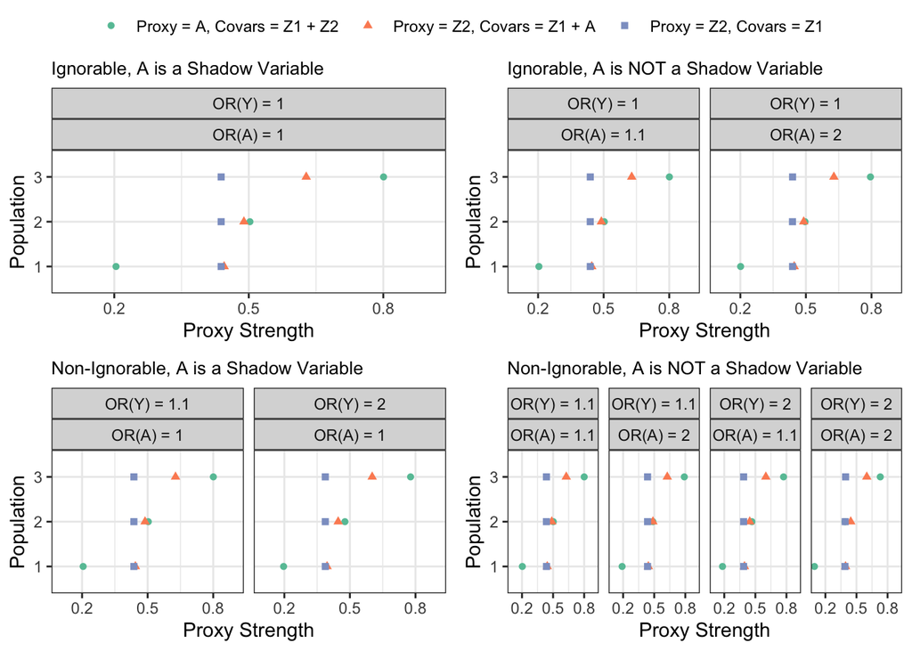

### Ignorable

OR(Y) = 1

- When OR(A) = 1:
  - Since A is not associated with selection (after conditioning on Z1 & Z2), leaving it out of the PPMM-Reg approach doesn’t lead to bias
  - True $\phi$ = 0 for all three specifications of the model
  - Thus, all are unbiased for $\phi=0$
- When OR(A) > 1:
  - True $\phi$ = 0 when A is included in the model (either as the proxy or as a covariate)
  - Excluding A leads to bias b/c A is being ignored but it is associated with selection
  - Thus, only the models that include A will be unbiased (with $\phi=0$)

#### Bias

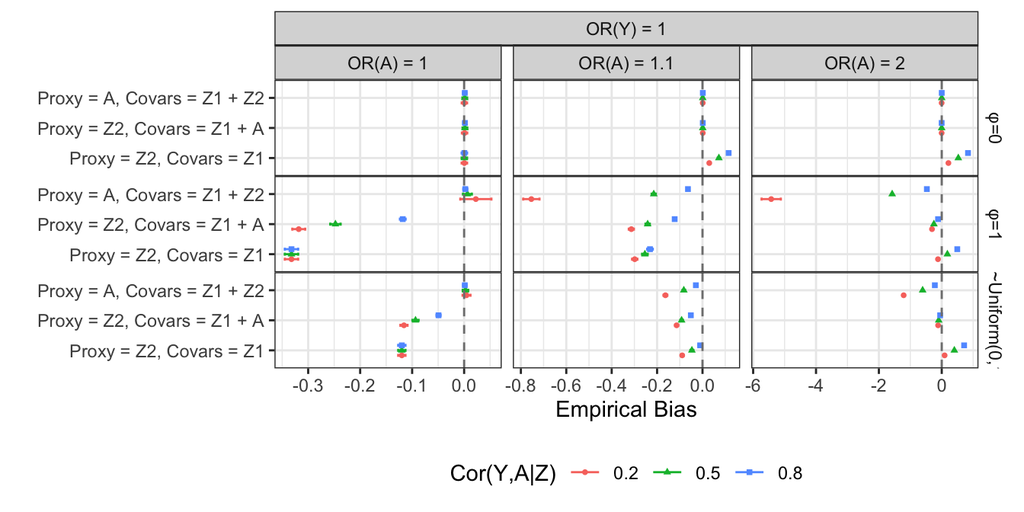

#### Coverage

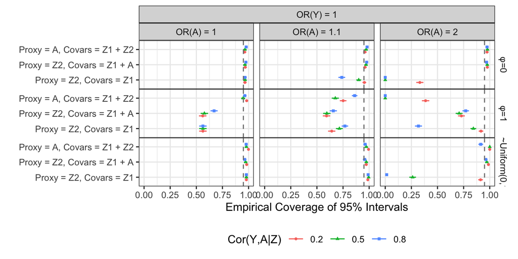

#### CI Width

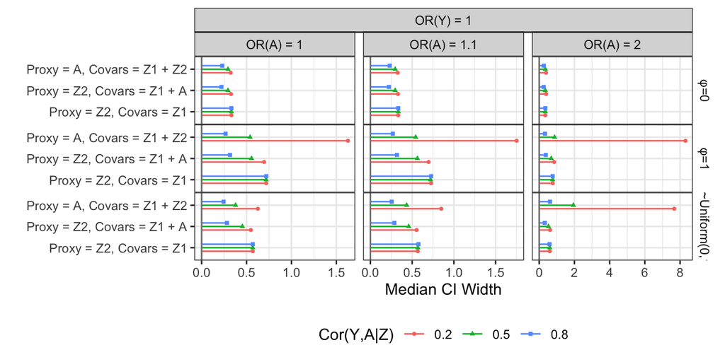

### Non-Ignorable, A is a Shadow Variable

OR(Y) = {1.1, 2} and OR(A) = 1

- When A is used as the proxy the true $\phi$ = 1 (since selection depends on Y and not on the proxy)
  - Thus, the original approach is unbiased with $\phi$ = 1
- When the role of A and Z2 are flipped, and Z2 is used to make the proxy, the true $\phi$ is somewhere between 0 and 1 since selection depends on both Y and the proxy
  - In this specific simulation design, when the OR(Y) and OR(Z2) are both 1.1, then the true $\phi$ will be close to 0.5 and thus $\phi$~Uniform will produce essentially unbiased results (since the point estimate will correspond to $\phi$ = 0.5 with the Uniform prior)
  - When OR(Y) = 2, $\phi$ is >0.5 (selection depends more strongly on Y than the proxy) so $\phi$~Uniform isn’t close to unbiased
- When A is not used at all, PPMM-Reg can still perform well because A isn’t associated with selection (so ignoring it is okay). The true $\phi$ is somewhere between 0 and 1, and in the case when OR(Y) = 1.1 we again have true $\phi$ close to 0.5, so $\phi$~Uniform will produce essentially unbiased results. When OR(Y) = 2, the true $\phi$ is again >0.5 so there is some bias with $\phi$~Uniform.

#### Bias

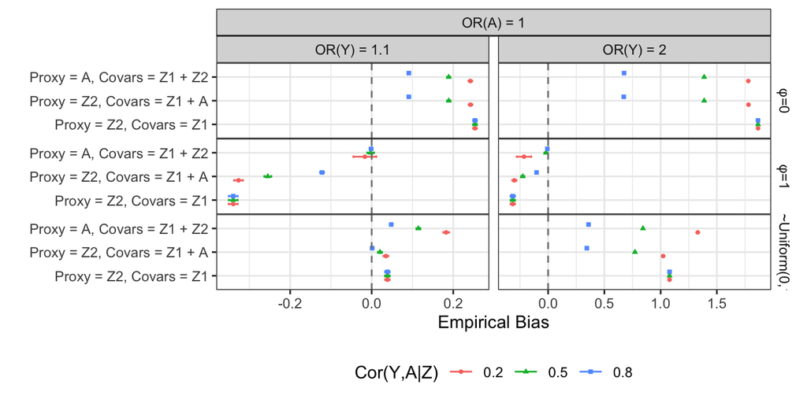

#### Coverage

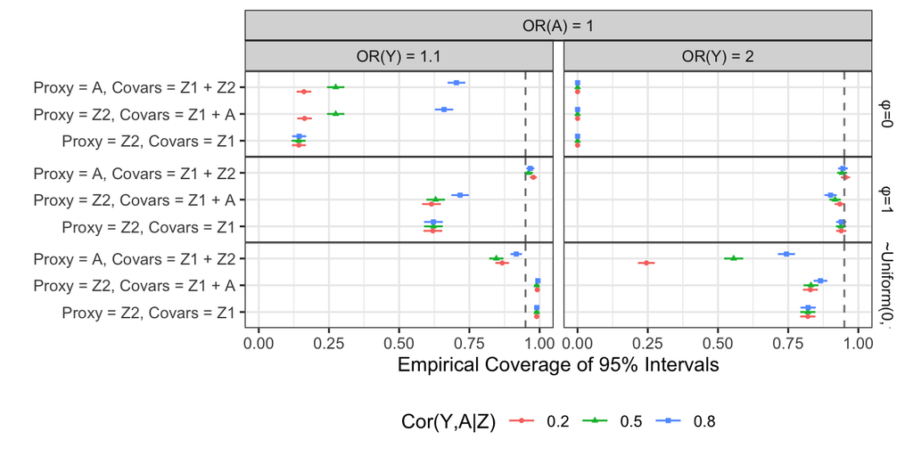

#### CI Width

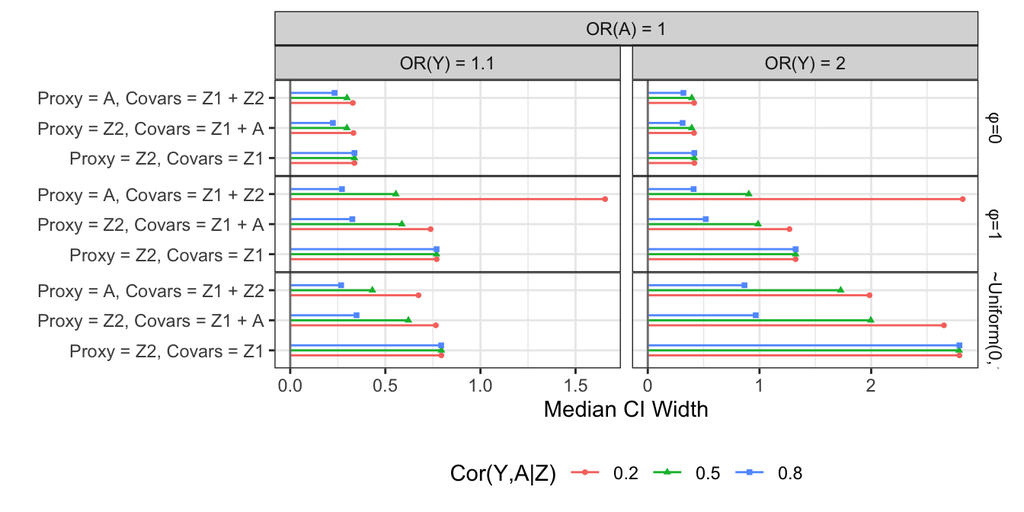

### Non-Ignorable, A is NOT a Shadow Variable

OR(Y) = {1.1, 2} and OR(A) = {1.1, 2}

- Flipping A and Z2 will have similar performance as original when OR(A) = 1.1 b/c that is the same OR as for Z2
- It will have different performance when OR(A) = 2 b/c that is different (larger) than the OR for Z2
- PPMM-Reg ignoring A will be biased (regardless of $\phi$) since A is associated with selection

#### Bias

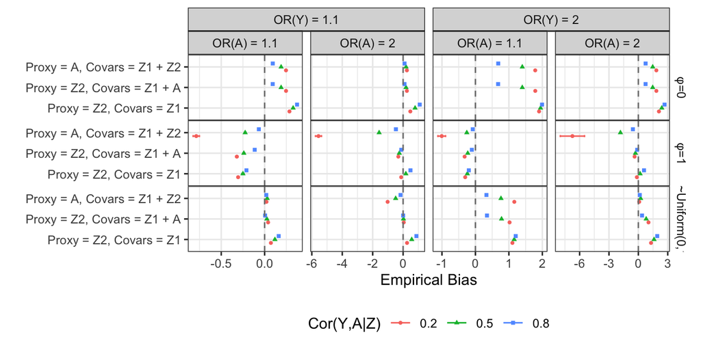

#### Coverage

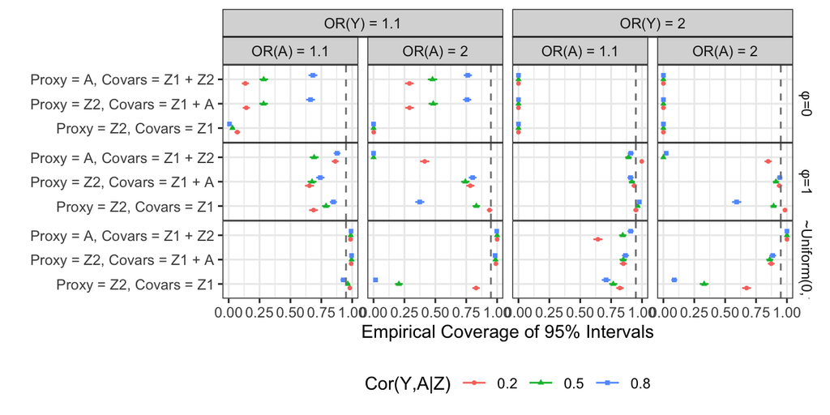

#### CI Width

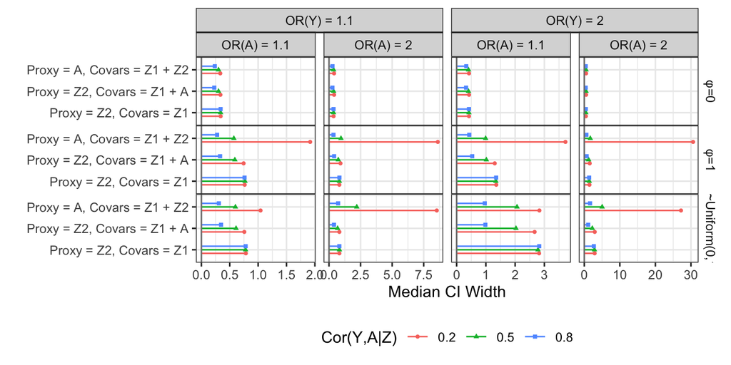